# PA1_template.Rmd

John Shomaker

June 4, 2016

# Reproducible Research: Assignment 1

## Activity Monitoring Data

The variables included in this dataset are:

**steps:** Number of steps taking in a 5-minute interval (missing values are coded as NA)  
**date:** The date on which the measurement was taken in YYYY-MM-DD format  
**interval:** Identifier for the 5-minute interval in which measurement was taken

The dataset is stored in a comma-separated-value (CSV) file and there are a total of 17,568 observations in this dataset.

## 1. Data Import & Cleaning

```r
## Install packages and libraries
## Download the activity.csv file and read to dataframe; initially omit NAs
## Convert 'date' column to date class; interval to factor

## install.packages("data.table")
## library(data.table)

filename <- "activity.csv"

if (!file.exists(filename)){
      fileURL <- "https://d396qusza40orc.cloudfront.net/repdata%2Fdata%2Factivity.zip"
      download.file(fileURL, filename, method="curl")
}

activity_all <- read.csv(filename, stringsAsFactors = FALSE, na.strings = "NA")
activity <- na.omit(activity_all)

activity$date <- as.Date(activity$date, "%m/%d/%y")
activity$interval <- factor(activity$interval)

options(scipen=999)
```

## 2. Total Steps Taken Each Day (Histogram)

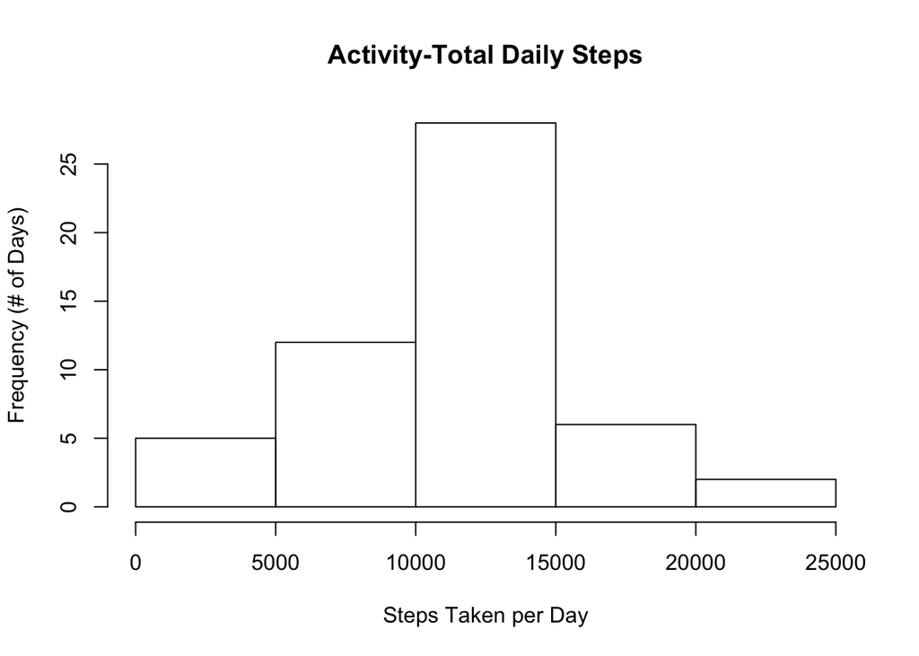

```r
## Summarize the total steps taken each day
## Create a histogram (frequency) of daily step count

activity_sum <- aggregate(steps ~ date, data = activity, sum)
hist(activity_sum$steps,
     main = "Activity-Total Daily Steps",
     xlab = "Steps Taken per Day", ylab = "Frequency (# of Days)")
```

## 3. Mean/Median Steps Taken Each Day

NOTE: Technically, it’s the mean/median of the daily step totals

```r
## Compute mean and median for the activity_sum (by day created in question #2)

activity_mean <- round(mean(activity_sum$steps), digits = 2)
activity_median <- median(activity_sum$steps)
```

The mean number of steps taken per day (across the sample number of days) is 10766.19. And, the median number of steps taken per day is 10765.

## 4. Time Series of Average Steps Taken

NOTE: Question is unclear, but given data set interpreted as a plot of the average (mean) steps per interval (across days), plotted by interval

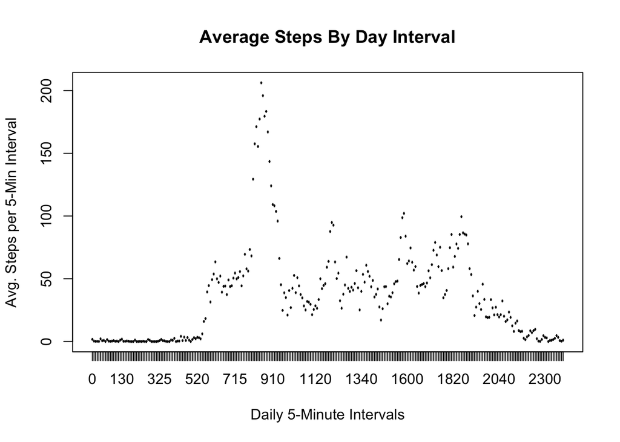

```r
## Find the average steps per interval across days
## Plot a line chart with intervals on x-axis

interval_avg <- aggregate(steps ~ interval, data = activity, mean)

plot(interval_avg$interval, interval_avg$steps, type = "l",
     xlab = "Daily 5-Minute Intervals", ylab = "Avg. Steps per 5-Min Interval",
     main = "Average Steps By Day Interval")
```

## 5. 5-Minute Interval with Greatest Average Steps

```r
## Find the interval with the largest average number of steps
## and present the interval number (factor) and steps amount

interval_sort <- interval_avg[order(interval_avg$steps), ]
interval_max <- interval_sort$interval[nrow(interval_sort)]
interval_max_amt <- round(interval_sort$steps[nrow(interval_sort)], digits = 2)
```

The 5-minutes interval with the greatest average steps is 835, which, on average, has 206.17 steps.

## 6. Imputing Data for Missing Data

Replace NA rows with average steps for the particular interval

```r
## Put missing rows in a separate dataframe
## Impute the missing steps value based on interval from interval_avg
## Insert the lookup value (via merge) and clean up table
## Show abbreviated head & tail of imputed table

missing <- subset(activity_all, is.na(steps))
imputed <- merge(missing, interval_avg, by="interval")
imputed <- imputed[, -2]
colnames(imputed)[3] <- "steps"

print(head(imputed, 6))
```

```
##   interval     date    steps
## 1        0  10/1/12 1.716981
## 2        0 11/30/12 1.716981
## 3        0  11/4/12 1.716981
## 4        0  11/9/12 1.716981
## 5        0 11/14/12 1.716981
## 6        0 11/10/12 1.716981
```

```r
print(tail(imputed, 6))
```

```
##      interval     date    steps
## 2299     2355  11/1/12 1.075472
## 2300     2355  10/8/12 1.075472
## 2301     2355  11/4/12 1.075472
## 2302     2355  11/9/12 1.075472
## 2303     2355  10/1/12 1.075472
## 2304     2355 11/30/12 1.075472
```

## 7. Total Steps Taken Each Day (Histogram) with Imputed Data

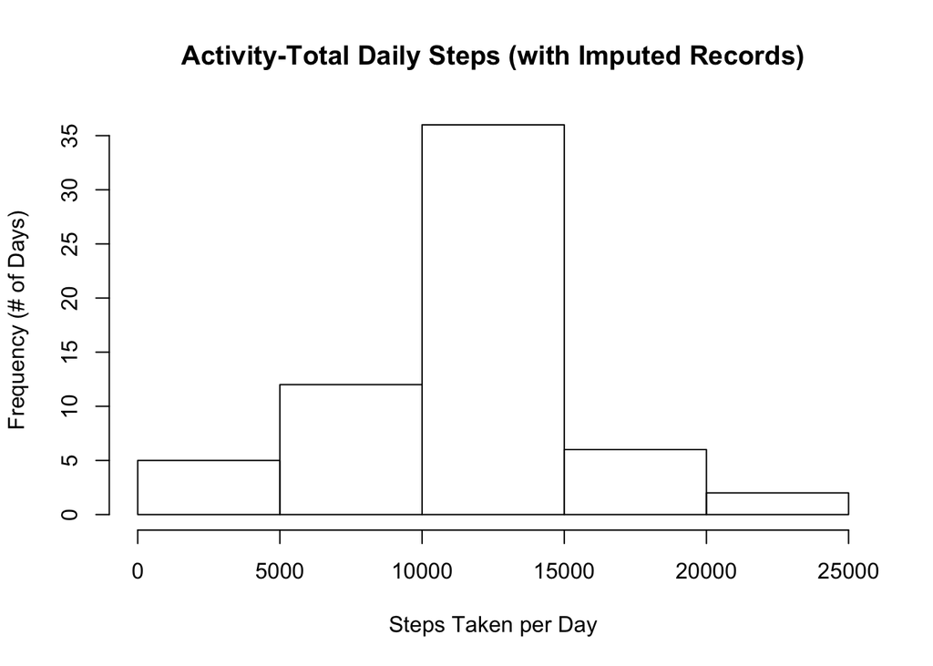

```r
## Bind the activity df (that excluded NAs) + the NA records (with imputed)
## First make sure class types and column positions match
## Recreate the histogram

imputed$date <- as.Date(imputed$date, "%m/%d/%y")
imputed$interval <- factor(imputed$interval)
imputed$steps <- as.integer(imputed$steps)

activity_temp <- activity[, c(2,3,1)]
imputed_temp <- imputed[, c(2,1,3)]

act_imp <- rbind(activity_temp, imputed_temp)

act_imp_sum <- aggregate(steps ~ date, data = act_imp, sum)
hist(act_imp_sum$steps,
     main = "Activity-Total Daily Steps (with Imputed Records)",
     xlab = "Steps Taken per Day", ylab = "Frequency (# of Days)")
```

## 8. Panel Plot Comparing Interval Steps - Weekdays vs. Weekends

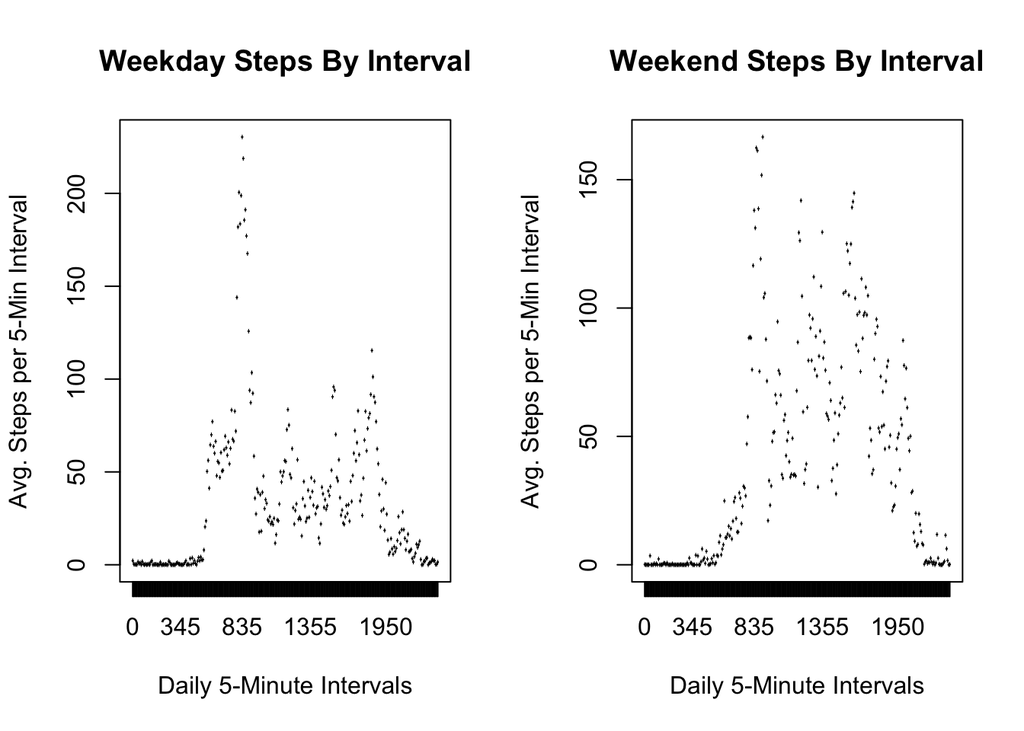

```r
## Subset the activity data (with imputed) for weekdays and weekends
## Searching for the first letter being an "S" is a short-cut
## For each subset find the mean number of steps by interval
## Merge the interval analyses to simplify plotting

act_wday <- subset(act_imp, substring(weekdays(act_imp$date), 1, 1) != "S")
act_wend <- subset(act_imp, substring(weekdays(act_imp$date), 1, 1) == "S")

wday_interval_avg <- aggregate(steps ~ interval, data = act_wday, mean)
wend_interval_avg <- aggregate(steps ~ interval, data = act_wend, mean)

wday_wend_avg <- merge(wday_interval_avg, wend_interval_avg, by = "interval")
colnames(wday_wend_avg)[2] <- "weekday_steps"
colnames(wday_wend_avg)[3] <- "weekend_steps"

par(mfrow = c(1, 2))

plot(wday_wend_avg$interval, wday_wend_avg$weekday_steps, type = "l",
     xlab = "Daily 5-Minute Intervals", ylab = "Avg. Steps per 5-Min Interval",
     main = "Weekday Steps By Interval")

plot(wday_wend_avg$interval, wday_wend_avg$weekend_steps, type = "l",
     xlab = "Daily 5-Minute Intervals", ylab = "Avg. Steps per 5-Min Interval",
     main = "Weekend Steps By Interval")
```